# 사피엔스 — 밀이 우리를 길들인 1만 년

Culture Voyager #5 | 인생을 바꾸는 책

Author

Nakcho Choi

Published

May 9, 2026

## 고백부터 하자

서른 즈음에 서점에서 이 책을 집어 들었다. 표지에 적힌 ’유인원에서 사이보그까지’라는 부제가 대단히 거만해 보여서, 솔직히 반쯤은 “이거 어디서 헛발 디디나 보자” 하는 심정이었다.

70페이지쯤에서 손이 멈췄다. 밀밭에 대한 이야기였다.

“밀이 사피엔스를 길들였다.” 이 한 문장이 머릿속에 박혔다. 우리가 밀을 재배한 게 아니라, 밀이라는 식물이 지구상에서 가장 성공적인 종이 되기 위해 인간이라는 노동력을 이용한 것이라는 역전. 우리가 주인이라고 믿었던 자리에, 사실은 다른 것이 앉아 있었다.

그 뒤로 이 책을 세 번 읽었다. 매번 다른 문장에서 멈추고, 매번 같은 질문 앞에 서게 된다: **우리가 ’당연하다’고 믿는 것 중에, 진짜로 당연한 게 있기는 한 건가?**

## 7만 년 전 — 거짓말이 시작된 밤

이 책에서 가장 결정적인 순간을 꼽으라면, 나는 인지혁명 챕터의 첫 단락을 고른다. 7만 년 전, 호모 사피엔스의 뇌에 무언가가 바뀌었다. 하라리는 그것을 “허구를 말할 수 있는 능력”이라고 부른다.

여기서 잠깐. 거짓말이 특별한 능력이라니?

그런데 생각해보면, 침팬지도 소통한다. “저기 사자가 있다!” — 이건 침팬지도 할 수 있다. 하지만 “우리 부족의 수호신이 저 산에 산다” — 이건 사피엔스만 가능하다. 존재하지 않는 것에 대해 말하는 능력. 이것이 전부의 시작이다.

국가, 종교, 인권, 돈, 법인 — 하라리가 “상상의 질서”라고 부르는 것들. 어느 것도 물리적 실체가 없다. 만져볼 수 없다. 하지만 충분히 많은 사람이 믿으면 — 진짜가 된다.

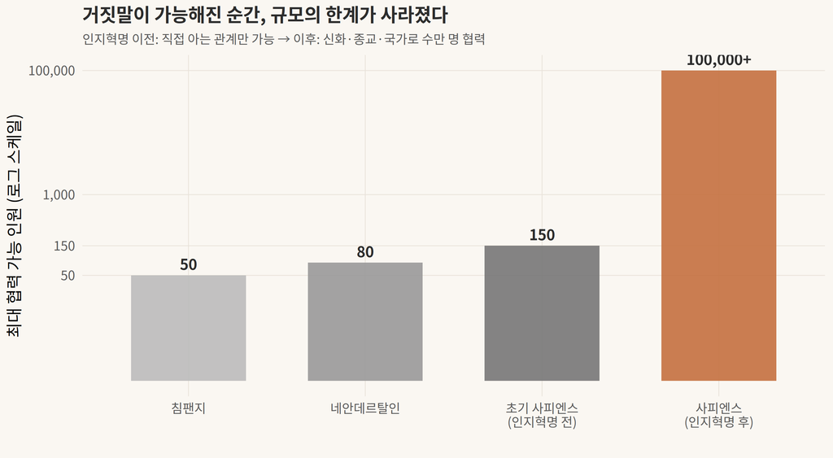

협력의 규모를 결정하는 것: 허구를 공유하는 능력

이 차트를 보면 심장이 뛴다. 인지혁명 전과 후의 차이가 양적인 것이 아니라 질적이다. 150명에서 10만 명으로의 도약 — 이것은 같은 종의 확장이 아니라, 완전히 다른 게임의 시작이다.

## 역사상 최대의 사기

이 책에서 가장 도발적인 챕터. 하라리는 농업혁명을 “역사상 최대의 사기”라고 부른다.

교과서에서 배운 이야기는 이랬다: 인류가 수렵채집 생활의 불안정에서 벗어나 농업을 시작하며 문명이 꽃피었다. 진보. 발전. 더 나은 삶.

하라리는 이것을 뒤집는다.

수렵채집인은 하루 3~4시간 일했다. 다양한 음식을 먹었다. 골격이 건강했다. 농부는? 하루 10시간 이상 밀밭에서 등을 구부렸다. 단일 작물에 의존해 영양이 불균형해졌다. 고대 농부의 뼈에서는 관절염, 추간판 탈출, 탈장의 흔적이 대량으로 발견된다.

그러면 왜 농업으로 갔는가? **아무도 선택하지 않았기 때문이다.** 한 세대가 밀을 조금 더 심으면, 인구가 조금 더 늘고, 다음 세대는 더 많은 밀이 필요하고, 더 많이 일해야 하고 — 되돌아갈 수 없다. 수렵채집 시절의 지식은 이미 잊혀졌으니까.

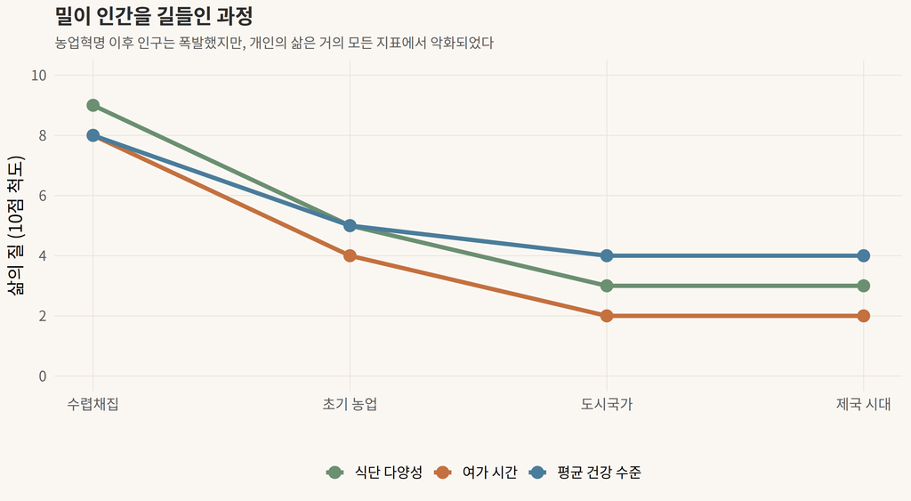

농업혁명의 역설 — ’진보’인 줄 알았는데 덫이었다

이것이 내가 서른에 이 책을 읽고 가장 오래 멈춘 대목이다. “밀이 사피엔스를 길들였다”는 문장은 수사가 아니라, 생물학적으로 정확한 묘사에 가깝다. 밀의 입장에서 보면 — 야생 잡초에서 지구 표면의 225만 평방킬로미터를 점령한 종으로 올라선 것이다. 사피엔스라는 노동력을 고용해서.

## 나는 왜 매달 통장에 숫자를 확인하는가

하라리의 세 번째 칼. **돈은 상호 신뢰의 시스템이다.**

모든 사람이 이 종이조각(혹은 디지털 숫자)의 가치를 믿기 때문에, 그것은 가치가 있다. 내일 아침 모두가 믿음을 철회하면, 지폐는 종이가 된다. 비트코인을 보라 — 이것은 하라리의 논지를 실시간으로 증명하고 있는 사회 실험이 아닌가.

국가도 마찬가지다. 대한민국이라는 실체를 만져본 사람은 없다. 땅은 있다. 사람은 있다. 하지만 ’대한민국’은 — 우리가 함께 믿기로 한 상상의 질서다. 그 믿음이 무너지는 순간을 우리는 ’혁명’이라고 부른다.

이 지점에서 책을 덮고 한참을 멍하니 있었던 기억이 난다. 내가 당연하다고 여기던 모든 것 — 직장, 국적, 법, 결혼 제도, 학위 — 이 모든 것이 “충분히 많은 사람이 믿기로 했기 때문에” 존재한다는 사실. 불안한가? 나는 오히려 해방감을 느꼈다. **당연한 게 없다는 건, 바꿀 수 있다는 뜻이기도 하니까.**

## 하라리는 누구인가 — 그리고 왜 이 책을 썼는가

[video not shown]

**TED Talk: Why humans run the world**

하라리가 사피엔스의 핵심 논지를 15분으로 압축한 강연. 침팬지와 인간의 협력 차이를 유쾌하게 풀어낸다.

이스라엘 하이파 출생. 히브리 대학교 역사학과 교수. 매일 2시간씩 위파사나 명상을 하는, 상당히 독특한 학자다. 그는 이 명상 습관이 “거대한 역사적 과정을 관찰하는 인내심”을 줬다고 말한다.

이 책은 원래 히브리어 대학 강의 노트에서 시작됐다. 2011년 히브리어로 출간, 2014년 영어 번역본이 나왔고 — 그 뒤는 우리가 아는 이야기다. 전 세계 65개 언어, 2,500만 부 이상 판매. 빌 게이츠는 “올해 읽은 최고의 책 10권”에 올렸고, 오바마는 추천 도서 목록에 넣었으며, 저커버그는 자신의 북클럽에서 이 책을 선정했다.

한국에서는 김영사에서 2015년 출간, 200쇄를 찍으며 115만 부 이상 팔렸다. 인문 교양서로서는 이례적인 숫자다.

## 이 책을 공격하는 사람들 — 그리고 그들이 틀리지 않는 이유

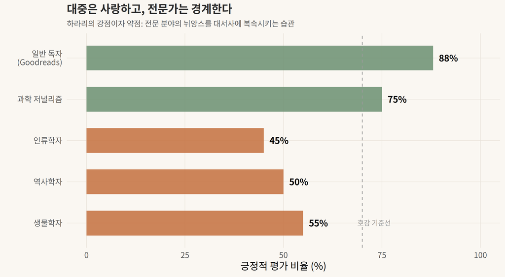

사피엔스에 대한 학계와 대중의 엇갈린 평가

공정하게 말하자. 이 책에는 문제가 있다.

인류학자들은 수렵채집 시대를 지나치게 낭만화했다고 비판한다. 실제로 수렵채집 사회의 폭력적 사망률은 상당히 높았다. 역사학자들은 7만 년을 500페이지에 압축하면서 불가피하게 발생하는 단순화를 지적한다. 신경과학자 다르샤나 나라야난은 “하라리의 오류는 수가 많고 실질적”이라고 날카롭게 비판했다.

맞는 말이다. 하지만 나는 이렇게 생각한다: **이 책의 가치는 정확성이 아니라 질문에 있다.** “왜 사피엔스가 지구를 지배하게 되었는가?”라는 질문 자체가, 우리를 겸손하게 만든다. 교과서적 정답을 기대하며 이 책을 읽으면 실망한다. 하지만 “내가 당연하게 여기던 것이 당연한 게 아닐 수도 있다”는 불편함을 기꺼이 받아들인다면 — 이 책은 인생의 렌즈를 교정하는 경험이 된다.

## 세 권의 거울 — 사피엔스는 어디에 서 있는가

**총, 균, 쇠** (1997) *“왜 유라시아가 아메리카를 정복했는가?”*

재레드 다이아몬드는 지리와 환경이 문명의 운명을 결정했다고 본다. 결정론적이지만 설득력 있다. 하라리와의 차이: 다이아몬드는 **물질적 조건**을, 하라리는 **인지적 조건**을 우선시한다.

**코스모스** (1980) *“우리는 별의 먼지로 만들어졌다”*

칼 세이건은 우주적 겸손을 가르쳤다. 하라리는 종(種)적 겸손을 가르친다. 코스모스가 “우주에서 우리의 위치”를 묻는다면, 사피엔스는 “지구에서 우리의 자격”을 묻는다.

**이기적 유전자** (1976) *“생존 기계로서의 인간”*

도킨스는 유전자 수준에서 이타성을 설명했다. 하라리는 한 발 더 나간다 — 유전자를 넘어 **문화적 허구**가 대규모 협력을 가능케 한다고. 도킨스의 ‘밈’ 개념을 역사 전체로 확장한 셈이다.

## 🎧 읽을 때 듣기 좋은 음악

[interactive chart not shown]

**Spotify: 사피엔스 오디오북**

데릭 퍼킨스의 낭독. 15시간 17분. 출퇴근길에 듣기에 적당하다. 하라리의 문장은 소리로 들을 때 더 흡인력이 있다.

## 그래서, 이 책을 읽은 뒤 나는

세 가지가 바뀌었다.

**첫째**, 뉴스를 다르게 본다. “국제 사회의 규범” “보편적 인권” “경제 성장” — 이 모든 표현 뒤에 “이것은 상상의 질서다”라는 각주가 자동으로 붙는다. 냉소가 아니다. 인간이 만든 것이니까, 인간이 바꿀 수도 있다는 가능성의 감각이다.

**둘째**, 밀밭을 지나갈 때 묘한 기분이 든다. 저 녀석이 나를 길들인 거구나. 1만 년 전에 우리 조상이 저 풀 앞에서 허리를 구부린 이후로, 우리는 한 번도 일어서지 못했다.

**셋째**, 겸손해졌다. 호모 사피엔스가 지구를 지배하게 된 것은 우리가 똑똑해서가 아니라, **함께 거짓말할 수 있어서**다. 이 거짓말이 신화가 되고, 종교가 되고, 국가가 되고, 주식회사가 되었다. 대단한 것인 동시에, 약간은 우스운 것이기도 하다.

하라리는 이 책의 마지막에서 묻는다: **“우리는 무엇을 원하고 싶은가?”** ‘무엇을 원하는가’가 아니라 ’무엇을 원하고 싶은가’. 이 미묘한 차이가, 이 책 전체를 관통하는 질문이다.

우리는 욕망조차 선택한 것이 아닐 수 있다. 밀이 우리를 길들였듯, 자본주의가, 소셜미디어가, 알고리즘이 우리의 욕망을 설계하고 있을 수 있다. 그것을 알아차리는 것 — 그것이 아마도, 이 시대의 인지혁명일 것이다.

*다음 호: 코스모스 — 칼 세이건이 선물한 우주적 겸손*

*Culture Voyager Vol.05 | 2026.05.09*